# EDA y clasificacion: Palmer Penguins

**Objetivo.** Explorar el conjunto de datos Palmer Penguins y construir un clasificador para predecir la especie (`Adelie`, `Chinstrap` o `Gentoo`) a partir de variables morfologicas y de contexto.

El flujo sigue una practica reproducible: limpieza minima, exploracion visual, particion entrenamiento/prueba, preprocesamiento dentro de `Pipeline`, comparacion de modelos y evaluacion final sobre datos no vistos.

```python
from pathlib import Path
import warnings

import matplotlib.pyplot as plt
import numpy as np
import pandas as pd
import seaborn as sns

from sklearn.compose import ColumnTransformer
from sklearn.dummy import DummyClassifier
from sklearn.ensemble import RandomForestClassifier
from sklearn.inspection import permutation_importance
from sklearn.linear_model import LogisticRegression
from sklearn.metrics import (
    ConfusionMatrixDisplay,
    accuracy_score,
    classification_report,
    f1_score,
)
from sklearn.model_selection import StratifiedKFold, cross_validate, train_test_split
from sklearn.neighbors import KNeighborsClassifier
from sklearn.pipeline import Pipeline
from sklearn.preprocessing import OneHotEncoder, StandardScaler
from sklearn.tree import DecisionTreeClassifier

warnings.filterwarnings("ignore")

sns.set_theme(
    style="ticks",
    context="notebook",
    rc={
        "axes.facecolor": "white",
        "figure.facecolor": "white",
        "axes.edgecolor": "#d1d5db",
        "axes.labelcolor": "#30343b",
        "xtick.color": "#4b5563",
        "ytick.color": "#4b5563",
        "grid.color": "#e5e7eb",
        "grid.linewidth": 0.7,
        "font.size": 10,
        "axes.titlesize": 12,
        "axes.titleweight": "bold",
    },
)

SPECIES_ORDER = ["Adelie", "Chinstrap", "Gentoo"]
SPECIES_PALETTE = {
    "Adelie": "#5BB7A5",
    "Chinstrap": "#E07A5F",
    "Gentoo": "#7D9CCB",
}
ACCENT_GREEN = "#6E9650"
ACCENT_RED = "#C76F6A"
ACCENT_GOLD = "#D2A84E"
INK = "#25313d"
MUTED = "#6b7280"

def clean_ax(ax, title=None, xlabel=None, ylabel=None, grid=True):
    ax.set_facecolor("white")
    ax.spines["top"].set_visible(False)
    ax.spines["right"].set_visible(False)
    ax.spines["left"].set_color("#d1d5db")
    ax.spines["bottom"].set_color("#d1d5db")
    ax.tick_params(labelsize=9, colors="#4b5563")
    if grid:
        ax.grid(True, axis="y", color="#e5e7eb", linewidth=0.7)
        ax.grid(False, axis="x")
    else:
        ax.grid(False)
    if title:
        ax.set_title(title, loc="left", pad=10, color=INK)
    if xlabel is not None:
        ax.set_xlabel(xlabel)
    if ylabel is not None:
        ax.set_ylabel(ylabel)
    return ax

DATA_URL = "https://raw.githubusercontent.com/mwaskom/seaborn-data/master/penguins.csv"
DATA_DIR = Path("data")
DATA_DIR.mkdir(exist_ok=True)
DATA_PATH = DATA_DIR / "penguins.csv"

if not DATA_PATH.exists():
    pd.read_csv(DATA_URL).to_csv(DATA_PATH, index=False)

penguins_raw = pd.read_csv(DATA_PATH)
penguins_raw.head()
```

|  | species | island | bill_length_mm | bill_depth_mm | flipper_length_mm | body_mass_g | sex |
| --- | --- | --- | --- | --- | --- | --- | --- |
| 0 | Adelie | Torgersen | 39.1 | 18.7 | 181.0 | 3750.0 | MALE |
| 1 | Adelie | Torgersen | 39.5 | 17.4 | 186.0 | 3800.0 | FEMALE |
| 2 | Adelie | Torgersen | 40.3 | 18.0 | 195.0 | 3250.0 | FEMALE |
| 3 | Adelie | Torgersen | NaN | NaN | NaN | NaN | NaN |
| 4 | Adelie | Torgersen | 36.7 | 19.3 | 193.0 | 3450.0 | FEMALE |

## 1. Estructura y calidad de datos

Primero revisamos tamano, tipos, valores faltantes y balance de clases. Esto determina si se puede entrenar directamente o si hay que imputar, eliminar o transformar variables.

```python
print(f"Filas: {penguins_raw.shape[0]:,}")
print(f"Columnas: {penguins_raw.shape[1]:,}")
display(penguins_raw.info())
display(penguins_raw.describe(include="all").T)
```

```
Filas: 344
Columnas: 7
<class 'pandas.core.frame.DataFrame'>
RangeIndex: 344 entries, 0 to 343
Data columns (total 7 columns):
 #   Column             Non-Null Count  Dtype
---  ------             --------------  -----
 0   species            344 non-null    object
 1   island             344 non-null    object
 2   bill_length_mm     342 non-null    float64
 3   bill_depth_mm      342 non-null    float64
 4   flipper_length_mm  342 non-null    float64
 5   body_mass_g        342 non-null    float64
 6   sex                333 non-null    object
dtypes: float64(4), object(3)
memory usage: 18.9+ KB
```

```
None
```

|  | count | unique | top | freq | mean | std | min | 25% | 50% | 75% | max |
| --- | --- | --- | --- | --- | --- | --- | --- | --- | --- | --- | --- |
| species | 344 | 3 | Adelie | 152 | NaN | NaN | NaN | NaN | NaN | NaN | NaN |
| island | 344 | 3 | Biscoe | 168 | NaN | NaN | NaN | NaN | NaN | NaN | NaN |
| bill_length_mm | 342.0 | NaN | NaN | NaN | 43.92193 | 5.459584 | 32.1 | 39.225 | 44.45 | 48.5 | 59.6 |
| bill_depth_mm | 342.0 | NaN | NaN | NaN | 17.15117 | 1.974793 | 13.1 | 15.6 | 17.3 | 18.7 | 21.5 |
| flipper_length_mm | 342.0 | NaN | NaN | NaN | 200.915205 | 14.061714 | 172.0 | 190.0 | 197.0 | 213.0 | 231.0 |
| body_mass_g | 342.0 | NaN | NaN | NaN | 4201.754386 | 801.954536 | 2700.0 | 3550.0 | 4050.0 | 4750.0 | 6300.0 |
| sex | 333 | 2 | MALE | 168 | NaN | NaN | NaN | NaN | NaN | NaN | NaN |

|  | faltantes | porcentaje |
| --- | --- | --- |
| species | 0 | 0.000000 |
| island | 0 | 0.000000 |
| bill_length_mm | 2 | 0.581395 |
| bill_depth_mm | 2 | 0.581395 |
| flipper_length_mm | 2 | 0.581395 |
| body_mass_g | 2 | 0.581395 |
| sex | 11 | 3.197674 |

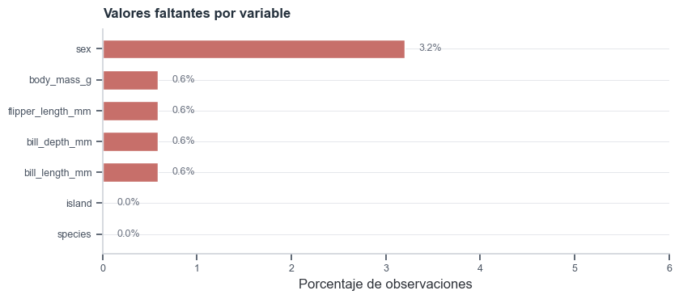

```python
missing = (
    penguins_raw.isna()
    .sum()
    .rename("faltantes")
    .to_frame()
    .assign(porcentaje=lambda x: 100 * x["faltantes"] / len(penguins_raw))
)
display(missing)

fig, ax = plt.subplots(figsize=(8.5, 3.8))
missing_plot = missing.sort_values("porcentaje")
colors = np.where(missing_plot["faltantes"] > 0, ACCENT_RED, "#9CA3AF")
ax.barh(missing_plot.index, missing_plot["porcentaje"], color=colors, height=0.62)
for y_pos, value in enumerate(missing_plot["porcentaje"]):
    ax.text(value + 0.15, y_pos, f"{value:.1f}%", va="center", fontsize=9, color=MUTED)
clean_ax(
    ax,
    title="Valores faltantes por variable",
    xlabel="Porcentaje de observaciones",
    ylabel="",
)
ax.set_xlim(0, max(6, missing_plot["porcentaje"].max() + 2))
plt.tight_layout()
plt.show()
```

|  | species | n |
| --- | --- | --- |
| 0 | Adelie | 152 |
| 1 | Gentoo | 124 |
| 2 | Chinstrap | 68 |

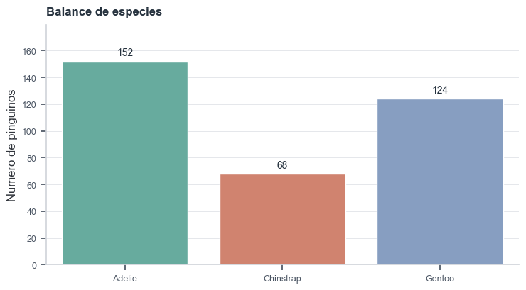

```python
class_counts = penguins_raw["species"].value_counts().rename_axis("species").reset_index(name="n")
display(class_counts)

fig, ax = plt.subplots(figsize=(7.5, 4.2))
sns.barplot(
    data=class_counts,
    x="species",
    y="n",
    order=SPECIES_ORDER,
    palette=SPECIES_PALETTE,
    ax=ax,
)
clean_ax(ax, title="Balance de especies", xlabel="", ylabel="Numero de pinguinos")
for container in ax.containers:
    ax.bar_label(container, padding=4, fontsize=10, color=INK)
ax.set_ylim(0, class_counts["n"].max() * 1.18)
plt.tight_layout()
plt.show()
```

Hay pocas observaciones con valores faltantes. Para evitar imputaciones innecesarias en un dataset pequeno, se eliminan solo las filas incompletas y se conserva el resto de la informacion.

```python
penguins = penguins_raw.dropna().copy()
print(f"Filas originales: {len(penguins_raw)}")
print(f"Filas completas: {len(penguins)}")
print(f"Filas eliminadas: {len(penguins_raw) - len(penguins)}")
```

```
Filas originales: 344
Filas completas: 333
Filas eliminadas: 11
```

## 2. Analisis exploratorio

Las variables morfologicas principales son longitud/profundidad del pico, longitud de aleta y masa corporal. Exploramos su distribucion por especie e isla para detectar separacion natural entre clases.

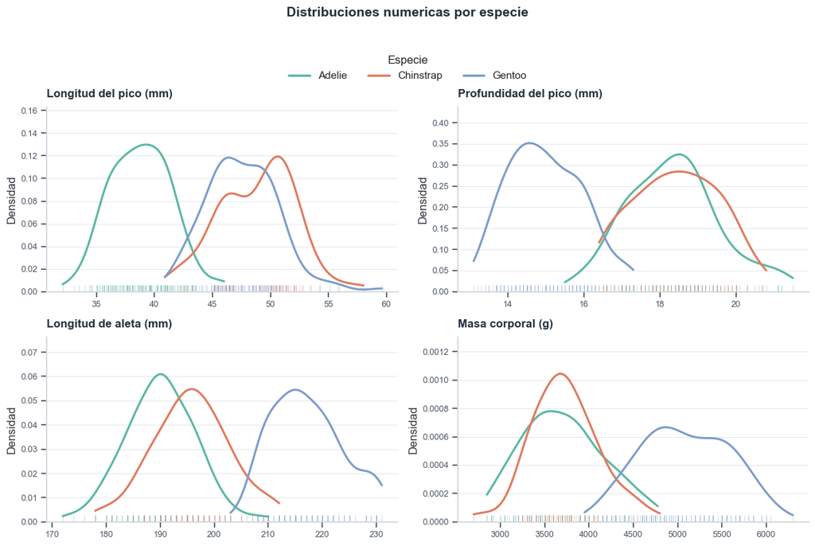

```python
numeric_features = ["bill_length_mm", "bill_depth_mm", "flipper_length_mm", "body_mass_g"]
categorical_features = ["island", "sex"]

feature_labels = {
    "bill_length_mm": "Longitud del pico (mm)",
    "bill_depth_mm": "Profundidad del pico (mm)",
    "flipper_length_mm": "Longitud de aleta (mm)",
    "body_mass_g": "Masa corporal (g)",
}

fig, axes = plt.subplots(2, 2, figsize=(12, 7.2))
axes = axes.ravel()
for ax, feature in zip(axes, numeric_features):
    for species in SPECIES_ORDER:
        subset = penguins.loc[penguins["species"] == species, feature]
        sns.kdeplot(
            x=subset,
            ax=ax,
            color=SPECIES_PALETTE[species],
            linewidth=2.2,
            fill=False,
            cut=0,
            label=species,
        )
        sns.rugplot(
            x=subset,
            ax=ax,
            height=0.035,
            color=SPECIES_PALETTE[species],
            alpha=0.32,
            linewidth=0.8,
        )
    clean_ax(ax, title=feature_labels[feature], xlabel="", ylabel="Densidad")
    legend = ax.get_legend()
    if legend is not None:
        legend.remove()
handles = [
    plt.Line2D([0], [0], color=SPECIES_PALETTE[species], lw=2.4, label=species)
    for species in SPECIES_ORDER
]
fig.legend(
    handles=handles,
    title="Especie",
    loc="upper center",
    bbox_to_anchor=(0.5, 1.02),
    ncol=3,
    frameon=False,
)
fig.suptitle("Distribuciones numericas por especie", y=1.10, fontsize=14, fontweight="bold", color=INK)
plt.tight_layout()
plt.show()
```

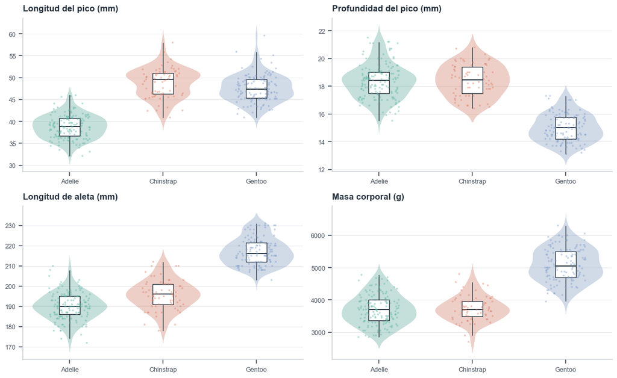

```python
fig, axes = plt.subplots(2, 2, figsize=(12, 7.4))
axes = axes.ravel()
for ax, feature in zip(axes, numeric_features):
    sns.violinplot(
        data=penguins,
        x="species",
        y=feature,
        order=SPECIES_ORDER,
        palette=SPECIES_PALETTE,
        inner=None,
        linewidth=0,
        alpha=0.38,
        ax=ax,
    )
    sns.boxplot(
        data=penguins,
        x="species",
        y=feature,
        order=SPECIES_ORDER,
        width=0.22,
        showcaps=False,
        boxprops={"facecolor": "white", "edgecolor": INK, "linewidth": 1.0},
        medianprops={"color": INK, "linewidth": 1.4},
        whiskerprops={"color": INK, "linewidth": 1.0},
        flierprops={"marker": "", "markersize": 0},
        ax=ax,
    )
    sns.stripplot(
        data=penguins,
        x="species",
        y=feature,
        order=SPECIES_ORDER,
        palette=SPECIES_PALETTE,
        size=2.7,
        alpha=0.42,
        jitter=0.22,
        ax=ax,
    )
    clean_ax(ax, title=feature_labels[feature], xlabel="", ylabel="")
plt.tight_layout()
plt.show()
```

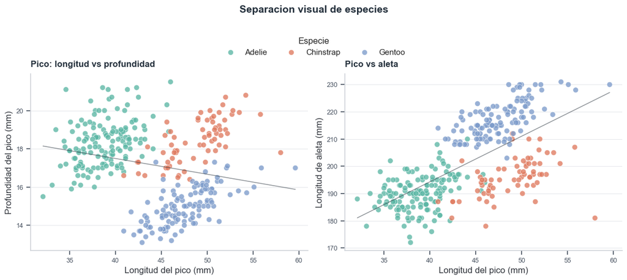

```python
fig, axes = plt.subplots(1, 2, figsize=(12, 4.7), sharey=False)

scatter_specs = [
    ("bill_length_mm", "bill_depth_mm", "Pico: longitud vs profundidad"),
    ("bill_length_mm", "flipper_length_mm", "Pico vs aleta"),
]

for ax, (x_var, y_var, title) in zip(axes, scatter_specs):
    sns.scatterplot(
        data=penguins,
        x=x_var,
        y=y_var,
        hue="species",
        hue_order=SPECIES_ORDER,
        palette=SPECIES_PALETTE,
        s=54,
        alpha=0.78,
        edgecolor="white",
        linewidth=0.5,
        ax=ax,
    )
    sns.regplot(
        data=penguins,
        x=x_var,
        y=y_var,
        scatter=False,
        ci=None,
        line_kws={"color": "#313b44", "lw": 1.1, "alpha": 0.55},
        ax=ax,
    )
    clean_ax(
        ax,
        title=title,
        xlabel=feature_labels[x_var],
        ylabel=feature_labels[y_var],
        grid=True,
    )
    legend = ax.get_legend()
    if legend is not None:
        legend.remove()

handles, labels = axes[0].get_legend_handles_labels()
fig.legend(
    handles,
    labels,
    title="Especie",
    loc="upper center",
    bbox_to_anchor=(0.5, 1.02),
    ncol=3,
    frameon=False,
)
fig.suptitle("Separacion visual de especies", y=1.12, fontsize=14, fontweight="bold", color=INK)
plt.tight_layout()
plt.show()
```

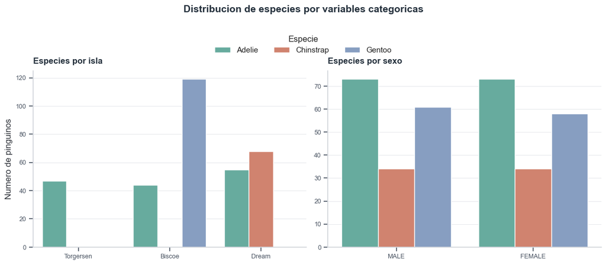

```python
fig, axes = plt.subplots(1, 2, figsize=(12, 4.6))
sns.countplot(
    data=penguins,
    x="island",
    hue="species",
    hue_order=SPECIES_ORDER,
    palette=SPECIES_PALETTE,
    ax=axes[0],
)
clean_ax(axes[0], title="Especies por isla", xlabel="", ylabel="Numero de pinguinos")
axes[0].legend_.remove()

sns.countplot(
    data=penguins,
    x="sex",
    hue="species",
    hue_order=SPECIES_ORDER,
    palette=SPECIES_PALETTE,
    ax=axes[1],
)
clean_ax(axes[1], title="Especies por sexo", xlabel="", ylabel="")
axes[1].legend_.remove()

handles, labels = axes[0].get_legend_handles_labels()
fig.legend(
    handles,
    labels,
    title="Especie",
    loc="upper center",
    bbox_to_anchor=(0.5, 1.02),
    ncol=3,
    frameon=False,
)
fig.suptitle("Distribucion de especies por variables categoricas", y=1.12, fontsize=14, fontweight="bold", color=INK)
plt.tight_layout()
plt.show()
```

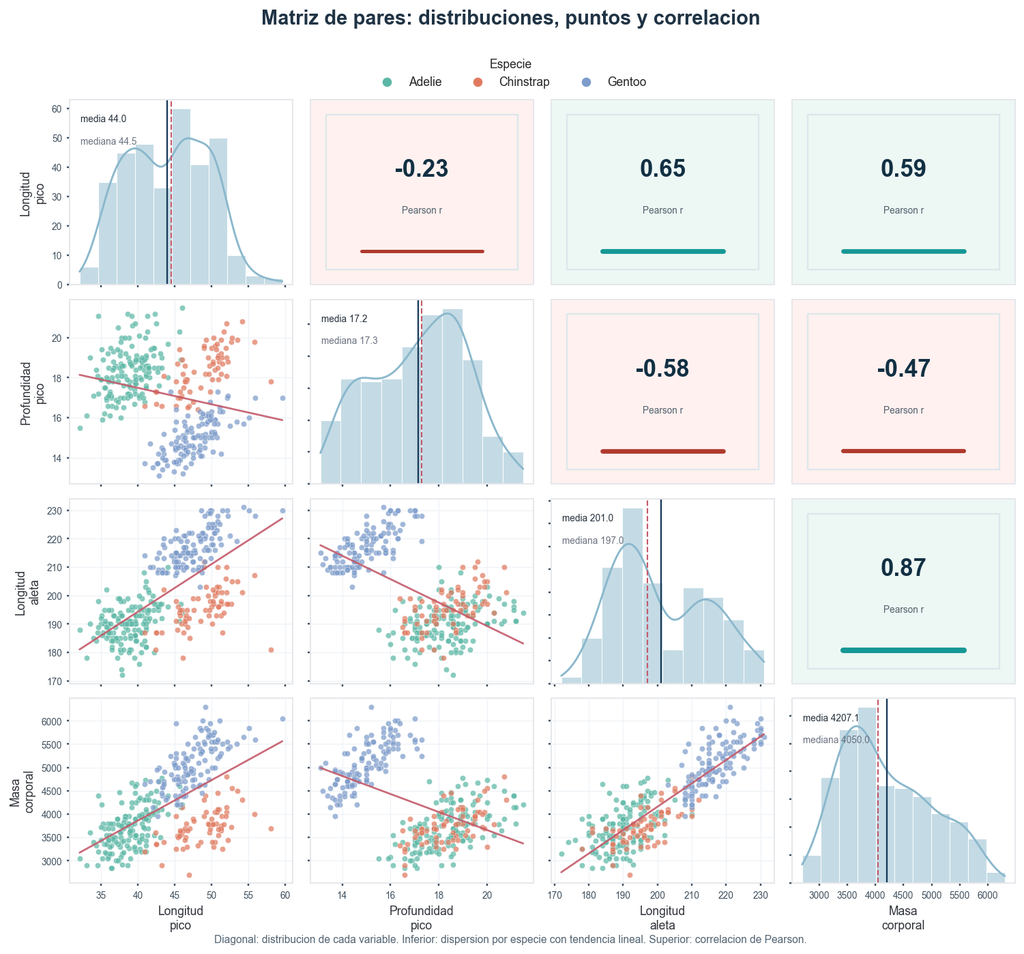

```python
pretty_names = {
    "bill_length_mm": "Longitud\npico",
    "bill_depth_mm": "Profundidad\npico",
    "flipper_length_mm": "Longitud\naleta",
    "body_mass_g": "Masa\ncorporal",
}
palette = SPECIES_PALETTE
n = len(numeric_features)
fig, axes = plt.subplots(n, n, figsize=(11, 10), dpi=140)
fig.patch.set_facecolor("white")

for i, y_var in enumerate(numeric_features):
    for j, x_var in enumerate(numeric_features):
        ax = axes[i, j]
        ax.set_facecolor("white")
        for spine in ax.spines.values():
            spine.set_color("#e5e7eb")
            spine.set_linewidth(1.0)

        if i == j:
            sns.histplot(
                data=penguins,
                x=x_var,
                kde=True,
                color="#8BB8CC",
                edgecolor="white",
                linewidth=0.5,
                ax=ax,
            )
            mean = penguins[x_var].mean()
            median = penguins[x_var].median()
            ax.axvline(mean, color="#183A59", lw=1.2, ls="-", label="media")
            ax.axvline(median, color="#C45A6A", lw=1.1, ls="--", label="mediana")
            ax.text(0.05, 0.88, f"media {mean:.1f}", transform=ax.transAxes, fontsize=7, color=INK)
            ax.text(0.05, 0.76, f"mediana {median:.1f}", transform=ax.transAxes, fontsize=7, color=MUTED)
            ax.set_ylabel("")

        elif i > j:
            for species, color in palette.items():
                subset = penguins[penguins["species"] == species]
                ax.scatter(
                    subset[x_var],
                    subset[y_var],
                    s=18,
                    alpha=0.72,
                    color=color,
                    edgecolors="white",
                    linewidths=0.25,
                )
            sns.regplot(
                data=penguins,
                x=x_var,
                y=y_var,
                scatter=False,
                ci=None,
                line_kws={"color": "#C45A6A", "lw": 1.4, "alpha": 0.9},
                ax=ax,
            )
            ax.grid(True, color="#eef2f7", linewidth=0.65)

        else:
            r = penguins[[x_var, y_var]].corr().iloc[0, 1]
            strength = min(abs(r), 1)
            face = "#edf7f4" if r >= 0 else "#fff1f0"
            accent = "#159895" if r >= 0 else "#B03A2E"
            ax.set_facecolor(face)
            ax.add_patch(
                plt.Rectangle(
                    (0.07, 0.08),
                    0.86,
                    0.84,
                    transform=ax.transAxes,
                    fill=False,
                    edgecolor="#dce7eb",
                    linewidth=1.2,
                )
            )
            ax.text(
                0.5,
                0.62,
                f"{r:.2f}",
                transform=ax.transAxes,
                ha="center",
                va="center",
                fontsize=18,
                fontweight="bold",
                color="#123043",
            )
            ax.text(
                0.5,
                0.40,
                "Pearson r",
                transform=ax.transAxes,
                ha="center",
                va="center",
                fontsize=7,
                color="#51606b",
            )
            ax.plot(
                [0.23, 0.77],
                [0.18, 0.18],
                transform=ax.transAxes,
                color=accent,
                lw=2 + 2.5 * strength,
                solid_capstyle="round",
            )
            ax.set_xticks([])
            ax.set_yticks([])

        if i < n - 1:
            ax.set_xticklabels([])
            ax.set_xlabel("")
        else:
            ax.set_xlabel(pretty_names[x_var], fontsize=9)

        if j > 0:
            ax.set_yticklabels([])
            ax.set_ylabel("")
        else:
            ax.set_ylabel(pretty_names[y_var], fontsize=9)

        ax.tick_params(axis="both", labelsize=7, length=2, colors="#40515f")

handles = [
    plt.Line2D(
        [0],
        [0],
        marker="o",
        color="w",
        label=species,
        markerfacecolor=color,
        markeredgecolor="white",
        markersize=8,
    )
    for species, color in palette.items()
]
fig.legend(
    handles=handles,
    title="Especie",
    loc="upper center",
    bbox_to_anchor=(0.5, 0.955),
    ncol=3,
    frameon=False,
    fontsize=9,
    title_fontsize=9,
)
fig.suptitle(
    "Matriz de pares: distribuciones, puntos y correlacion",
    y=0.995,
    fontsize=15,
    fontweight="bold",
    color="#1f3344",
)
fig.text(
    0.5,
    0.018,
    "Diagonal: distribucion de cada variable. Inferior: dispersion por especie con tendencia lineal. Superior: correlacion de Pearson.",
    ha="center",
    fontsize=8,
    color="#526371",
)
plt.subplots_adjust(top=0.90, bottom=0.08, left=0.08, right=0.98, wspace=0.08, hspace=0.08)
plt.show()
```

**Lecturas del EDA.**

- `Gentoo` queda muy separado por aletas mas largas y mayor masa corporal.
- `Adelie` y `Chinstrap` se parecen mas, pero la longitud y profundidad del pico ayudan a distinguirlas.
- La isla aporta informacion, aunque no conviene depender solo de ella: un clasificador robusto debe aprovechar tambien medidas fisicas.
- La correlacion entre masa y longitud de aleta sugiere redundancia parcial, pero ambas pueden aportar senal.

## 3. Preparacion para clasificacion

Usamos `species` como variable objetivo. Las variables numericas se estandarizan para modelos sensibles a escala y las categoricas se codifican con one-hot encoding. Todo el preprocesamiento vive dentro del `Pipeline` para evitar fuga de informacion entre entrenamiento y prueba.

### Modelos comparados

En este ejercicio se comparan cinco modelos. La idea no es solo escoger el que tenga mejor metrica, sino tener una referencia simple, un modelo lineal interpretable y modelos no lineales que puedan capturar relaciones mas flexibles.

**1. Baseline: clase mayoritaria**

Predice siempre la especie mas frecuente en el conjunto de entrenamiento. Sirve como punto minimo de comparacion: cualquier modelo util debe mejorar este resultado.

$$ \hat{y} = \arg\max_{c \in \mathcal{C}} n_c $$

donde $n_c$ es el numero de observaciones de la clase $c$.

**2. Regresion logistica multinomial**

Estima la probabilidad de cada especie usando una funcion softmax. Para una observacion con variables $\mathbf{x} = (x_1, x_2, \ldots, x_p)$, el modelo calcula un score lineal por clase:

$$ \eta_k = \beta_{0k} + \beta_{1k}x_1 + \beta_{2k}x_2 + \cdots + \beta_{pk}x_p $$

Luego transforma esos scores en probabilidades:

$$ P(Y = k \mid \mathbf{x}) = \frac{e^{\eta_k}}{\sum_{j=1}^{K} e^{\eta_j}} $$

La prediccion final es la clase con mayor probabilidad:

$$ \hat{y} = \arg\max_{k} P(Y = k \mid \mathbf{x}) $$

Si fuera clasificacion binaria, la forma clasica se escribe como:

$$ \log\left(\frac{p}{1-p}\right) = \beta_0 + \beta_1x_1 + \beta_2x_2 + \cdots + \beta_px_p $$

donde $p = P(Y=1 \mid \mathbf{x})$.

**3. K vecinos mas cercanos (KNN)**

Clasifica una observacion usando las clases de sus $K$ vecinos mas cercanos. En este notebook se usa $K=7$. La distancia se calcula despues de estandarizar variables numericas.

$$ \hat{y} = \operatorname{moda}\{y_i: i \in N_K(\mathbf{x})\} $$

**4. Arbol de decision**

Divide el espacio de variables con reglas del tipo $x_j \leq t$. En cada hoja predice la clase mas frecuente. Es interpretable, pero puede sobreajustar si se deja crecer demasiado; por eso se limita la profundidad.

**5. Random forest**

Entrena muchos arboles sobre muestras aleatorias y combina sus votos. Reduce la varianza de un solo arbol y suele funcionar bien cuando hay relaciones no lineales o interacciones entre variables.

$$ \hat{y} = \operatorname{moda}\{T_1(\mathbf{x}), T_2(\mathbf{x}), \ldots, T_B(\mathbf{x})\} $$

donde $T_b$ es el arbol numero $b$ del bosque.

```python
X = penguins[numeric_features + categorical_features]
y = penguins["species"]

X_train, X_test, y_train, y_test = train_test_split(
    X,
    y,
    test_size=0.25,
    random_state=42,
    stratify=y,
)

print("Entrenamiento:", X_train.shape)
print("Prueba:", X_test.shape)
display(y_train.value_counts(normalize=True).rename("proporcion_train"))
display(y_test.value_counts(normalize=True).rename("proporcion_test"))
```

```
Entrenamiento: (249, 6)
Prueba: (84, 6)
```

```
species
Adelie       0.437751
Gentoo       0.357430
Chinstrap    0.204819
Name: proporcion_train, dtype: float64
```

```
species
Adelie       0.440476
Gentoo       0.357143
Chinstrap    0.202381
Name: proporcion_test, dtype: float64
```

```python
preprocess = ColumnTransformer(
    transformers=[
        ("num", StandardScaler(), numeric_features),
        ("cat", OneHotEncoder(handle_unknown="ignore"), categorical_features),
    ]
)

models = {
    "Baseline: clase mayoritaria": DummyClassifier(strategy="most_frequent"),
    "Regresion logistica": LogisticRegression(max_iter=1000, multi_class="auto"),
    "KNN": KNeighborsClassifier(n_neighbors=7),
    "Arbol de decision": DecisionTreeClassifier(max_depth=4, random_state=42),
    "Random forest": RandomForestClassifier(
        n_estimators=400,
        max_depth=5,
        min_samples_leaf=3,
        random_state=42,
    ),
}

cv = StratifiedKFold(n_splits=5, shuffle=True, random_state=42)
results = []

for name, model in models.items():
    pipe = Pipeline([("preprocess", preprocess), ("model", model)])
    scores = cross_validate(
        pipe,
        X_train,
        y_train,
        cv=cv,
        scoring=["accuracy", "f1_macro"],
        return_train_score=True,
    )
    results.append(
        {
            "modelo": name,
            "accuracy_cv_media": scores["test_accuracy"].mean(),
            "accuracy_cv_sd": scores["test_accuracy"].std(),
            "f1_macro_cv_media": scores["test_f1_macro"].mean(),
            "f1_macro_cv_sd": scores["test_f1_macro"].std(),
            "accuracy_train_media": scores["train_accuracy"].mean(),
        }
    )

results_df = pd.DataFrame(results).sort_values("f1_macro_cv_media", ascending=False)
display(results_df.style.format({col: "{:.3f}" for col in results_df.columns if col != "modelo"}))
```

|  | modelo | accuracy_cv_media | accuracy_cv_sd | f1_macro_cv_media | f1_macro_cv_sd | accuracy_train_media |
| --- | --- | --- | --- | --- | --- | --- |
| 1 | Regresion logistica | 0.996 | 0.008 | 0.995 | 0.009 | 0.997 |
| 2 | KNN | 0.992 | 0.010 | 0.991 | 0.012 | 0.996 |
| 4 | Random forest | 0.984 | 0.020 | 0.981 | 0.023 | 0.995 |
| 3 | Arbol de decision | 0.972 | 0.030 | 0.969 | 0.031 | 0.993 |
| 0 | Baseline: clase mayoritaria | 0.438 | 0.010 | 0.203 | 0.003 | 0.438 |

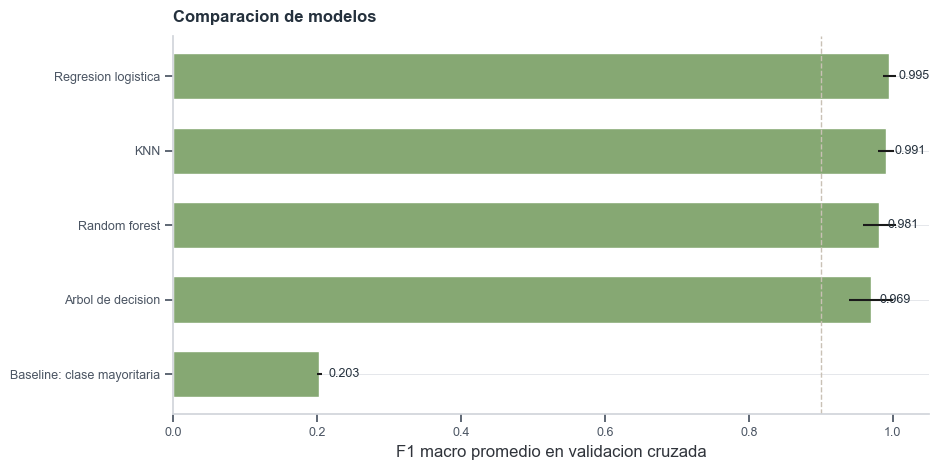

```python
fig, ax = plt.subplots(figsize=(9.5, 4.8))
plot_df = results_df.sort_values("f1_macro_cv_media")
ax.barh(
    plot_df["modelo"],
    plot_df["f1_macro_cv_media"],
    xerr=plot_df["f1_macro_cv_sd"],
    color="#86A873",
    edgecolor="white",
    height=0.62,
)
ax.set_xlim(0, 1.05)
clean_ax(
    ax,
    title="Comparacion de modelos",
    xlabel="F1 macro promedio en validacion cruzada",
    ylabel="",
)
ax.axvline(0.90, color="#c9c1b5", lw=1.0, ls="--")
for i, value in enumerate(plot_df["f1_macro_cv_media"]):
    ax.text(value + 0.012, i, f"{value:.3f}", va="center", fontsize=9, color=INK)
plt.tight_layout()
plt.show()
```

## 4. Evaluacion final

Seleccionamos el mejor modelo por F1 macro en validacion cruzada, lo ajustamos con todo el conjunto de entrenamiento y evaluamos una sola vez sobre la prueba retenida.

```python
best_name = results_df.iloc[0]["modelo"]
best_model = models[best_name]
best_pipe = Pipeline([("preprocess", preprocess), ("model", best_model)])
best_pipe.fit(X_train, y_train)

y_pred = best_pipe.predict(X_test)
test_accuracy = accuracy_score(y_test, y_pred)
test_f1_macro = f1_score(y_test, y_pred, average="macro")

print(f"Mejor modelo por CV: {best_name}")
print(f"Accuracy en prueba: {test_accuracy:.3f}")
print(f"F1 macro en prueba: {test_f1_macro:.3f}")
print()
print(classification_report(y_test, y_pred))
```

```
Mejor modelo por CV: Regresion logistica
Accuracy en prueba: 0.988
F1 macro en prueba: 0.986

              precision    recall  f1-score   support

      Adelie       1.00      0.97      0.99        37
   Chinstrap       0.94      1.00      0.97        17
      Gentoo       1.00      1.00      1.00        30

    accuracy                           0.99        84
   macro avg       0.98      0.99      0.99        84
weighted avg       0.99      0.99      0.99        84
```

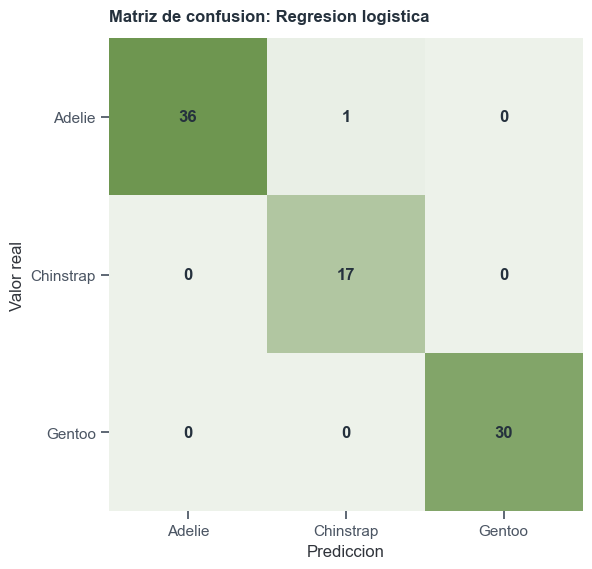

```python
fig, ax = plt.subplots(figsize=(6.8, 5.8))
ConfusionMatrixDisplay.from_predictions(
    y_test,
    y_pred,
    display_labels=SPECIES_ORDER,
    cmap=sns.light_palette("#6E9650", as_cmap=True),
    colorbar=False,
    ax=ax,
    text_kw={"fontsize": 12, "fontweight": "bold", "color": INK},
)
ax.set_title(f"Matriz de confusion: {best_name}", loc="left", pad=12, color=INK)
ax.set_xlabel("Prediccion")
ax.set_ylabel("Valor real")
ax.grid(False)
for spine in ax.spines.values():
    spine.set_visible(False)
plt.tight_layout()
plt.show()
```

|  | feature | importance_mean | importance_sd |
| --- | --- | --- | --- |
| 0 | bill_length_mm | 0.283625 | 0.040421 |
| 1 | bill_depth_mm | 0.032699 | 0.016900 |
| 2 | body_mass_g | 0.009500 | 0.014243 |
| 3 | island | 0.003212 | 0.009411 |
| 4 | flipper_length_mm | 0.001651 | 0.004290 |
| 5 | sex | 0.000222 | 0.011084 |

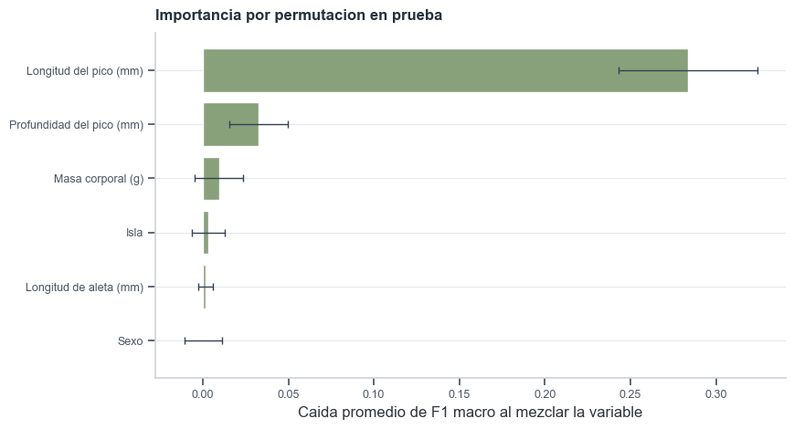

```python
perm = permutation_importance(
    best_pipe,
    X_test,
    y_test,
    n_repeats=30,
    random_state=42,
    scoring="f1_macro",
)

importance = (
    pd.DataFrame(
        {
            "feature": X_test.columns,
            "importance_mean": perm.importances_mean,
            "importance_sd": perm.importances_std,
        }
    )
    .sort_values("importance_mean", ascending=False)
    .reset_index(drop=True)
)
display(importance)

readable_importance = importance.copy()
readable_importance["feature"] = readable_importance["feature"].map(feature_labels | {"island": "Isla", "sex": "Sexo"})

fig, ax = plt.subplots(figsize=(8.8, 4.8))
sns.barplot(
    data=readable_importance,
    y="feature",
    x="importance_mean",
    color="#86A873",
    edgecolor="white",
    ax=ax,
)
ax.errorbar(
    readable_importance["importance_mean"],
    np.arange(len(readable_importance)),
    xerr=readable_importance["importance_sd"],
    fmt="none",
    ecolor="#334155",
    capsize=3,
    lw=1,
)
clean_ax(
    ax,
    title="Importancia por permutacion en prueba",
    xlabel="Caida promedio de F1 macro al mezclar la variable",
    ylabel="",
)
plt.tight_layout()
plt.show()
```

## 5. Modelo interpretable con solo variables morfologicas

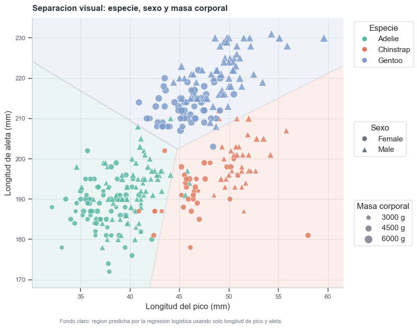

```python
two_features = ["bill_length_mm", "flipper_length_mm"]
simple_pipe = Pipeline(
    [
        ("scale", StandardScaler()),
        ("model", LogisticRegression(max_iter=1000)),
    ]
)
simple_pipe.fit(X_train[two_features], y_train)

x_min, x_max = X[two_features[0]].min() - 2, X[two_features[0]].max() + 2
y_min, y_max = X[two_features[1]].min() - 4, X[two_features[1]].max() + 4
xx, yy = np.meshgrid(np.linspace(x_min, x_max, 300), np.linspace(y_min, y_max, 300))
grid = pd.DataFrame({two_features[0]: xx.ravel(), two_features[1]: yy.ravel()})
zz = simple_pipe.predict(grid).reshape(xx.shape)

label_order = list(simple_pipe.named_steps["model"].classes_)
label_to_int = {label: idx for idx, label in enumerate(label_order)}
zz_int = np.vectorize(label_to_int.get)(zz)

from matplotlib.colors import ListedColormap

boundary_colors = [SPECIES_PALETTE[label] for label in label_order]
boundary_cmap = ListedColormap(boundary_colors)

fig, ax = plt.subplots(figsize=(10.4, 6.8))
ax.contourf(
    xx,
    yy,
    zz_int,
    alpha=0.12,
    levels=np.arange(len(label_order) + 1) - 0.5,
    cmap=boundary_cmap,
)
ax.contour(
    xx,
    yy,
    zz_int,
    levels=np.arange(len(label_order)) + 0.5,
    colors="#d1d5db",
    linewidths=0.8,
    alpha=0.9,
)

size_values = penguins["body_mass_g"]
size_scaled = pd.Series(
    np.interp(size_values, (size_values.min(), size_values.max()), (38, 145)),
    index=penguins.index,
)
sex_markers = {"FEMALE": ("o", "Female"), "MALE": ("^", "Male")}
for species in SPECIES_ORDER:
    for sex, (marker, sex_label) in sex_markers.items():
        subset = penguins[(penguins["species"] == species) & (penguins["sex"] == sex)]
        if subset.empty:
            continue
        ax.scatter(
            subset[two_features[0]],
            subset[two_features[1]],
            s=size_scaled.loc[subset.index],
            c=SPECIES_PALETTE[species],
            marker=marker,
            label=f"{species} - {sex_label}",
            alpha=0.82,
            edgecolors="white",
            linewidths=0.55,
        )

clean_ax(
    ax,
    title="Separacion visual: especie, sexo y masa corporal",
    xlabel="Longitud del pico (mm)",
    ylabel="Longitud de aleta (mm)",
    grid=True,
)
ax.grid(True, color="#e5e7eb", linewidth=0.75)

species_handles = [
    plt.Line2D(
        [0],
        [0],
        marker="o",
        color="w",
        label=species,
        markerfacecolor=SPECIES_PALETTE[species],
        markeredgecolor="white",
        markersize=8,
    )
    for species in SPECIES_ORDER
]
sex_handles = [
    plt.Line2D(
        [0],
        [0],
        marker=marker,
        color="w",
        label=sex_label,
        markerfacecolor="#6b7280",
        markeredgecolor="white",
        markersize=8,
    )
    for sex, (marker, sex_label) in sex_markers.items()
]
size_handles = [
    plt.scatter([], [], s=size, color="#4b5563", alpha=0.65, edgecolors="white", linewidths=0.5, label=label)
    for size, label in zip([45, 85, 130], ["3000 g", "4500 g", "6000 g"])
]
legend1 = ax.legend(
    handles=species_handles,
    title="Especie",
    loc="upper left",
    bbox_to_anchor=(1.02, 1.0),
    frameon=True,
    facecolor="white",
    edgecolor="#d1d5db",
)
ax.add_artist(legend1)
legend2 = ax.legend(
    handles=sex_handles,
    title="Sexo",
    loc="upper left",
    bbox_to_anchor=(1.02, 0.63),
    frameon=True,
    facecolor="white",
    edgecolor="#d1d5db",
)
ax.add_artist(legend2)
ax.legend(
    handles=size_handles,
    title="Masa corporal",
    loc="upper left",
    bbox_to_anchor=(1.02, 0.34),
    frameon=True,
    facecolor="white",
    edgecolor="#d1d5db",
)
fig.text(
    0.12,
    0.035,
    "Fondo claro: region predicha por la regresion logistica usando solo longitud de pico y aleta.",
    fontsize=8,
    color=MUTED,
)
plt.tight_layout(rect=[0, 0.05, 0.82, 1])
plt.show()
```